# 003 hospdays

Katie Gostic

11/1/2017

#### Note: hospdays records the number of days hospitalized after study enrollment. In another script, I test tothosp (the total number of hospitalized days). I try to control for hospitalization unrelated to infelunza by excluding patients with underlying conditions from the tothosp analysis

Notes on data formatting from Deborah Wentworth:

- symdur is symptom duration (days) prior to enrollment
- date info is for enrollment date
- fluvac6 and fluvac12 are flu vaccination in last 6 or last 12 months
- anyvac combines values from fluvac6 and fluvac12, whichever was collected for a given patient is reported.
- anyav is use of antivirals at any time
- anydx is any diagnosis in the medical history section
- flutype is subtype: 1=H1N1, 2=H3N2, 3=flu B, 4=PCR negative, 5=Inf A, subtype unknown, and 6=coinfection with multiple strains
- resolved is symptom resolution within 14 days
- country code is the 3 letter code for country of enrollment - think the abbreviations will be obvious

#### Visualize the relationship between age and duration of hospitalization

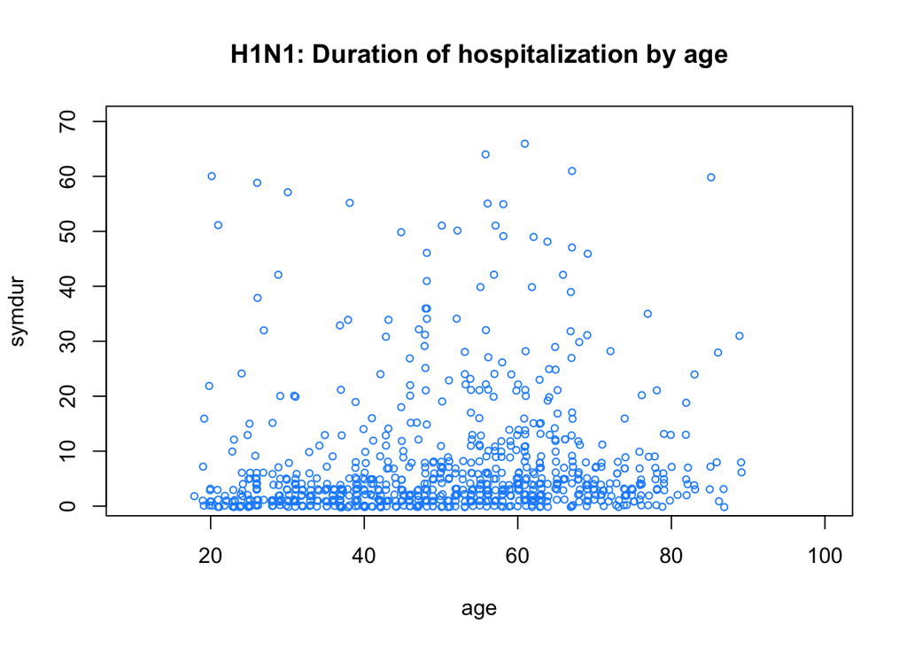

```
##
##  Spearman's rank correlation rho
##
## data:  valid$age and valid$hospdays
## S = 56530000, p-value = 2.296e-10
## alternative hypothesis: true rho is not equal to 0
## sample estimates:
##      rho
## 0.227336
```

There is a positive correlation between age and duration of hospitalization.

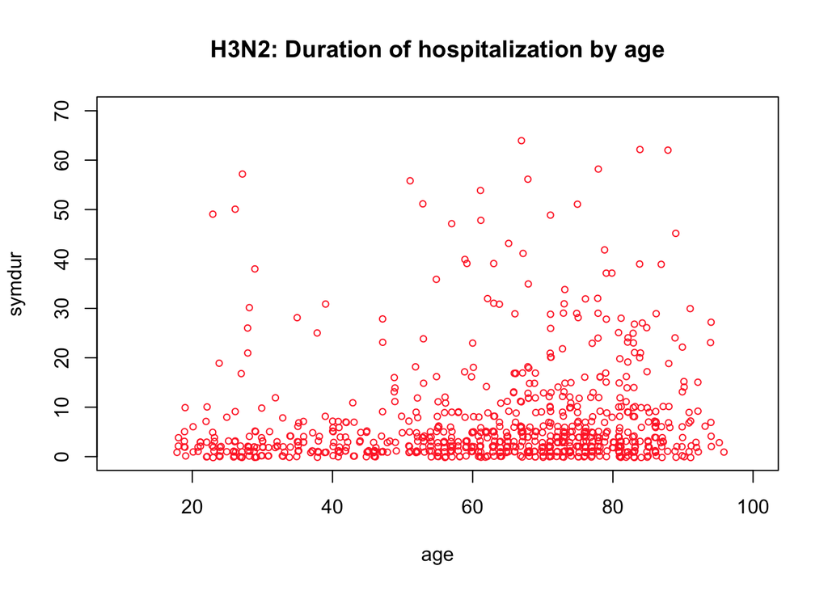

```
##
##  Spearman's rank correlation rho
##
## data:  valid$age and valid$hospdays
## S = 59538000, p-value = 1.403e-07
## alternative hypothesis: true rho is not equal to 0
## sample estimates:
##       rho
## 0.1894313
```

Results show a positive correlation between duration of hosp and age.

#### Visualize the relationship between country and symptom duration

H1N1

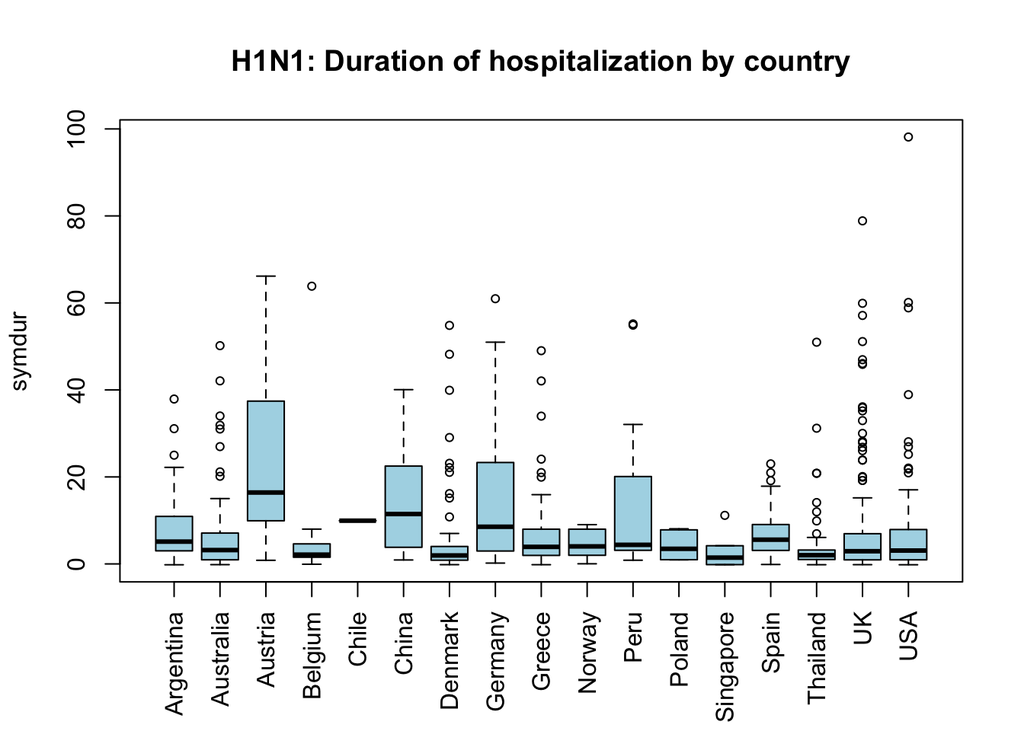

H3N2

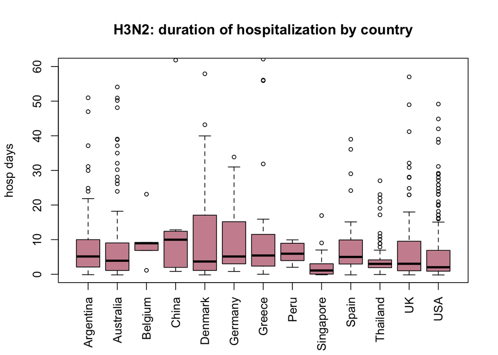

# No clear effect of country

#### Visualize the relationship between season and symptom duration

H1N1

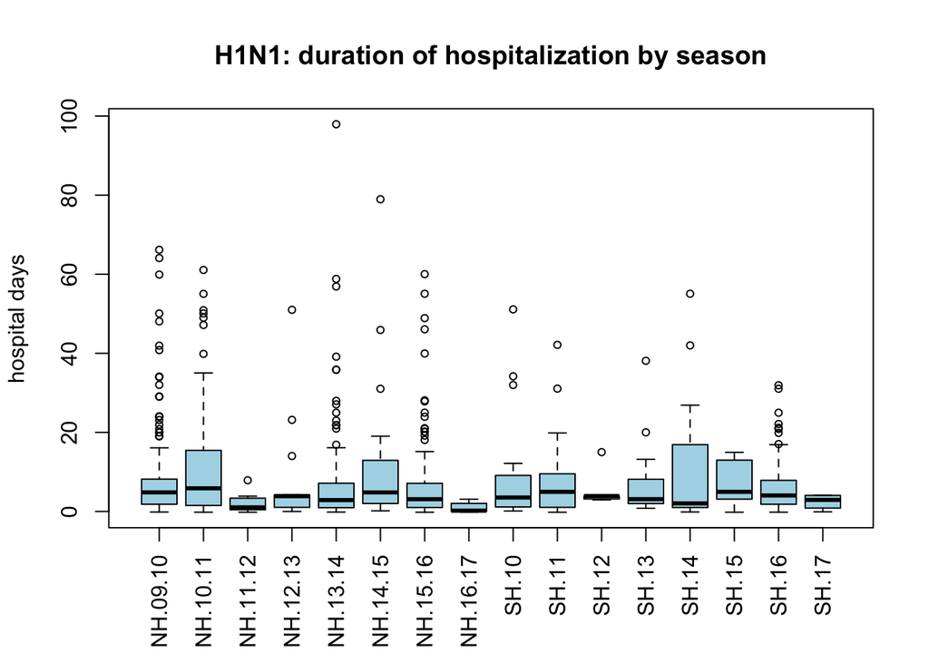

No clear effect of season.

H3N2

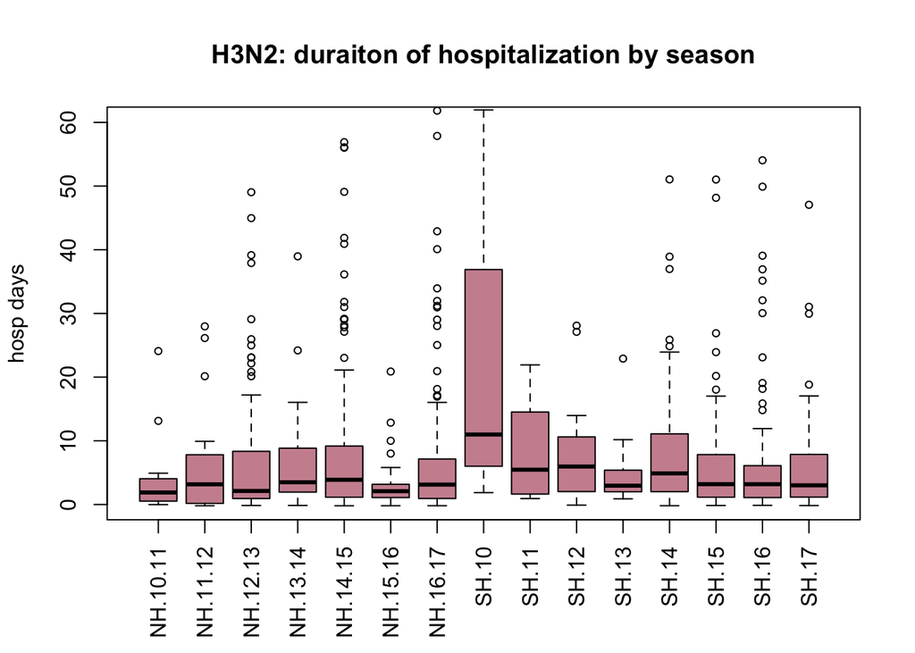

No clear effect of season –> Try models that don’t include season and country as blocking vars

- age
- imprinting status
- vaccination status
- antiviral use
- season
- country

### Clean data for fitting

```
##
## Argentina Australia   Austria   Belgium     Chile     China   Denmark
##        51        70         8        11         1        16        71
##   Germany    Greece    Norway      Peru    Poland Singapore     Spain
##        44        90         7        17         6         7        43
##  Thailand        UK       USA
##        64       145       120
```

```
## [1] 771
```

```
##
## Argentina Australia   Belgium     China   Denmark   Germany    Greece
##       117       123         5         7        32        21        24
##      Peru Singapore     Spain  Thailand        UK       USA
##         9        24        31       125        93       180
```

```
## [1] 791
```

### First fit a model where the only independent variable is age

Treat vaccination, antivial use, underlying symptoms, country and season as blocking variables with fixed effects

```r
library(splines)
## H1N1 fit to medical history only (no effect of country, season, age or imprinting)
fit00 = glm(hospdays ~ anyav + anydx  + H3.valid*anyvac, data = train)
summary(fit00)
```

```
##
## Call:
## glm(formula = hospdays ~ anyav + anydx + H3.valid * anyvac, data = train)
##
## Deviance Residuals:
##     Min       1Q   Median       3Q      Max
##  -9.040   -6.040   -3.400    0.065  139.425
##
## Coefficients:
##                   Estimate Std. Error t value Pr(>|t|)
## (Intercept)         5.0466     1.0112   4.991 6.83e-07 ***
## anyav1              0.3533     0.8436   0.419   0.6754
## anydx1              3.6399     0.8060   4.516 6.87e-06 ***
## H3.valid1          -1.4646     0.8127  -1.802   0.0718 .
## anyvac1            -2.0485     1.0284  -1.992   0.0466 *
## H3.valid1:anyvac1   2.5542     1.3524   1.889   0.0592 .
## ---
## Signif. codes:  0 '***' 0.001 '**' 0.01 '*' 0.05 '.' 0.1 ' ' 1
##
## (Dispersion parameter for gaussian family taken to be 133.7321)
##
##     Null deviance: 178412  on 1315  degrees of freedom
## Residual deviance: 175189  on 1310  degrees of freedom
##   (90 observations deleted due to missingness)
## AIC: 10186
##
## Number of Fisher Scoring iterations: 2
```

```r
## H1N1 fit to country, season and medical history only (no effect of age or imprinting)
fit0 = glm(hospdays ~ anyav + anydx + country + H3.valid*season + H3.valid*anyvac, data = train)
summary(fit0)
```

```
##
## Call:
## glm(formula = hospdays ~ anyav + anydx + country + H3.valid *
##     season + H3.valid * anyvac, data = train)
##
## Deviance Residuals:
##     Min       1Q   Median       3Q      Max
## -15.234   -5.581   -3.000    0.852  135.227
##
## Coefficients: (1 not defined because of singularities)
##                           Estimate Std. Error t value Pr(>|t|)
## (Intercept)                4.41934    2.38453   1.853 0.064066 .
## anyav1                     1.20390    0.87673   1.373 0.169939
## anydx1                     3.09939    0.83692   3.703 0.000222 ***
## countryAustralia          -1.77864    1.65831  -1.073 0.283671
## countryBelgium             1.89808    4.55377   0.417 0.676885
## countryDenmark            -2.79222    2.24189  -1.245 0.213188
## countryGermany             5.01117    2.45456   2.042 0.041399 *
## countryGreece             -0.53751    2.19394  -0.245 0.806499
## countryOther               1.84354    2.29142   0.805 0.421237
## countrySpain              -0.25484    2.33879  -0.109 0.913249
## countryThailand           -3.93521    1.74166  -2.259 0.024024 *
## countryUK                 -0.67537    1.97640  -0.342 0.732619
## countryUSA                -2.77791    1.95958  -1.418 0.156550
## countrySingapore          -8.25040    3.09522  -2.666 0.007784 **
## H3.valid1                  7.45202    6.14265   1.213 0.225295
## seasonNH.10.11             4.65555    1.70224   2.735 0.006326 **
## seasonNH.11.12            -1.99173    4.87867  -0.408 0.683156
## seasonNH.12.13            -0.25177    3.72788  -0.068 0.946164
## seasonNH.13.14             1.43771    1.69416   0.849 0.396250
## seasonNH.14.15             4.67410    3.54394   1.319 0.187440
## seasonNH.15.16             0.14078    1.52604   0.092 0.926513
## seasonNH.16.17            -4.48858    4.27906  -1.049 0.294394
## seasonSH.10                5.03573    3.31157   1.521 0.128597
## seasonSH.11                1.50654    3.22476   0.467 0.640453
## seasonSH.12               -2.50898    5.38359  -0.466 0.641265
## seasonSH.13                0.03158    3.34811   0.009 0.992475
## seasonSH.14                7.52872    4.06442   1.852 0.064208 .
## seasonSH.15                0.43207    4.72140   0.092 0.927100
## seasonSH.16                0.27667    2.12628   0.130 0.896492
```

[output cut: 14 more lines]

```
## H3.valid1:seasonSH.15     -7.76844    7.71586  -1.007 0.314216
## H3.valid1:seasonSH.16     -5.72810    6.53922  -0.876 0.381217
## H3.valid1:seasonSH.17           NA         NA      NA       NA
## H3.valid1:anyvac1          1.43964    1.42581   1.010 0.312832
## ---
## Signif. codes:  0 '***' 0.001 '**' 0.01 '*' 0.05 '.' 0.1 ' ' 1
##
## (Dispersion parameter for gaussian family taken to be 130.4805)
##
##     Null deviance: 178412  on 1315  degrees of freedom
## Residual deviance: 165710  on 1270  degrees of freedom
##   (90 observations deleted due to missingness)
## AIC: 10192
##
## Number of Fisher Scoring iterations: 2
```

```r
## H1N1 fit to age only, plus fixed effects of vaccination, av use, underlying conditions, country and season
fit1 = glm(hospdays ~ ns(age, knots = 65) + anyav + anydx + country + H3.valid*season + H3.valid*anyvac, data = train)
summary(fit1)
```

```
##
## Call:
## glm(formula = hospdays ~ ns(age, knots = 65) + anyav + anydx +
##     country + H3.valid * season + H3.valid * anyvac, data = train)
##
## Deviance Residuals:
##     Min       1Q   Median       3Q      Max
## -16.635   -5.550   -2.986    0.920  134.728
##
## Coefficients: (1 not defined because of singularities)
##                            Estimate Std. Error t value Pr(>|t|)
## (Intercept)                2.474391   2.502701   0.989  0.32300
## ns(age, knots = 65)1       7.146935   2.313084   3.090  0.00205 **
## ns(age, knots = 65)2       2.715974   1.773937   1.531  0.12601
## anyav1                     1.218379   0.873914   1.394  0.16351
## anydx1                     2.206418   0.876126   2.518  0.01191 *
## countryAustralia          -1.464845   1.658042  -0.883  0.37715
## countryBelgium             2.882068   4.547134   0.634  0.52631
## countryDenmark            -2.192511   2.242752  -0.978  0.32846
## countryGermany             5.723169   2.454676   2.332  0.01988 *
## countryGreece             -0.705893   2.187035  -0.323  0.74693
## countryOther               2.037185   2.283783   0.892  0.37255
## countrySpain              -0.142995   2.331065  -0.061  0.95110
## countryThailand           -3.710429   1.737207  -2.136  0.03288 *
## countryUK                  0.005694   1.982298   0.003  0.99771
## countryUSA                -2.086821   1.968292  -1.060  0.28925
## countrySingapore          -7.990848   3.101845  -2.576  0.01010 *
## H3.valid1                  7.569692   6.129344   1.235  0.21706
## seasonNH.10.11             4.268066   1.700194   2.510  0.01219 *
## seasonNH.11.12            -1.683928   4.865033  -0.346  0.72930
## seasonNH.12.13            -1.120130   3.724073  -0.301  0.76363
## seasonNH.13.14             1.042705   1.692097   0.616  0.53786
## seasonNH.14.15             4.150967   3.539154   1.173  0.24107
## seasonNH.15.16            -0.534610   1.533646  -0.349  0.72746
## seasonNH.16.17            -4.927188   4.265360  -1.155  0.24824
## seasonSH.10                5.658126   3.305938   1.712  0.08723 .
## seasonSH.11                1.843400   3.214590   0.573  0.56644
## seasonSH.12               -1.508869   5.374101  -0.281  0.77894
## seasonSH.13                0.426352   3.338716   0.128  0.89841
## seasonSH.14                7.217968   4.052210   1.781  0.07511 .
```

[output cut: 16 more lines]

```
## H3.valid1:seasonSH.15     -8.087451   7.689247  -1.052  0.29310
## H3.valid1:seasonSH.16     -6.200579   6.517413  -0.951  0.34159
## H3.valid1:seasonSH.17            NA         NA      NA       NA
## H3.valid1:anyvac1          1.466401   1.421890   1.031  0.30260
## ---
## Signif. codes:  0 '***' 0.001 '**' 0.01 '*' 0.05 '.' 0.1 ' ' 1
##
## (Dispersion parameter for gaussian family taken to be 129.5243)
##
##     Null deviance: 178412  on 1315  degrees of freedom
## Residual deviance: 164237  on 1268  degrees of freedom
##   (90 observations deleted due to missingness)
## AIC: 10185
##
## Number of Fisher Scoring iterations: 2
```

```r
## H1N1 fit to age plus imprinting, plus fixed effects of vaccination, av use, underlying conditions, country and season
fit2 = glm(hospdays ~ ns(age, knots = 65) +p.protected + anyav + anydx + country + H3.valid*season + H3.valid*anyvac, data = train)
summary(fit2)
```

```
##
## Call:
## glm(formula = hospdays ~ ns(age, knots = 65) + p.protected +
##     anyav + anydx + country + H3.valid * season + H3.valid *
##     anyvac, data = train)
##
## Deviance Residuals:
##     Min       1Q   Median       3Q      Max
## -17.039   -5.500   -2.964    0.929  134.986
##
## Coefficients: (1 not defined because of singularities)
##                            Estimate Std. Error t value Pr(>|t|)
## (Intercept)                1.988397   2.547428   0.781  0.43521
## ns(age, knots = 65)1       7.085042   2.313836   3.062  0.00224 **
## ns(age, knots = 65)2       3.016219   1.798065   1.677  0.09370 .
## p.protected                0.932203   0.912065   1.022  0.30694
## anyav1                     1.260561   0.874873   1.441  0.14987
## anydx1                     2.189681   0.876263   2.499  0.01258 *
## countryAustralia          -1.434479   1.658279  -0.865  0.38718
## countryBelgium             3.078801   4.551126   0.676  0.49885
## countryDenmark            -2.113333   2.244050  -0.942  0.34650
## countryGermany             5.831883   2.456937   2.374  0.01776 *
## countryGreece             -0.786011   2.188400  -0.359  0.71953
## countryOther               2.008759   2.283912   0.880  0.37928
## countrySpain              -0.078491   2.331878  -0.034  0.97315
## countryThailand           -3.671714   1.737589  -2.113  0.03479 *
## countryUK                  0.009542   1.982267   0.005  0.99616
## countryUSA                -2.154959   1.969386  -1.094  0.27406
## countrySingapore          -7.810228   3.106821  -2.514  0.01206 *
## H3.valid1                  8.051606   6.147345   1.310  0.19051
## seasonNH.10.11             4.179877   1.702352   2.455  0.01421 *
## seasonNH.11.12            -1.655061   4.865030  -0.340  0.73377
## seasonNH.12.13            -1.264651   3.726691  -0.339  0.73440
## seasonNH.13.14             1.080839   1.692479   0.639  0.52319
## seasonNH.14.15             4.044567   3.540622   1.142  0.25353
## seasonNH.15.16            -0.584072   1.534382  -0.381  0.70352
## seasonNH.16.17            -5.066846   4.267473  -1.187  0.23532
## seasonSH.10                5.699783   3.306131   1.724  0.08495 .
## seasonSH.11                1.928688   3.215617   0.600  0.54875
## seasonSH.12               -1.407613   5.374919  -0.262  0.79345
```

[output cut: 18 more lines]

```
## H3.valid1:seasonSH.15     -8.111330   7.689147  -1.055  0.29167
## H3.valid1:seasonSH.16     -6.351285   6.518966  -0.974  0.33010
## H3.valid1:seasonSH.17            NA         NA      NA       NA
## H3.valid1:anyvac1          1.742856   1.447364   1.204  0.22875
## ---
## Signif. codes:  0 '***' 0.001 '**' 0.01 '*' 0.05 '.' 0.1 ' ' 1
##
## (Dispersion parameter for gaussian family taken to be 129.5197)
##
##     Null deviance: 178412  on 1315  degrees of freedom
## Residual deviance: 164101  on 1267  degrees of freedom
##   (90 observations deleted due to missingness)
## AIC: 10186
##
## Number of Fisher Scoring iterations: 2
```

```r
## H1N1 fit to age only, plus fixed effects of vaccination, av use, underlying conditions NO COUNTRY AND SEASON
fit3 = glm(hospdays ~ ns(age, knots = 65) + anyav + anydx  + H3.valid*anyvac, data = train)
summary(fit3)
```

```
##
## Call:
## glm(formula = hospdays ~ ns(age, knots = 65) + anyav + anydx +
##     H3.valid * anyvac, data = train)
##
## Deviance Residuals:
##     Min       1Q   Median       3Q      Max
## -10.600   -5.819   -3.315    0.294  138.893
##
## Coefficients:
##                      Estimate Std. Error t value Pr(>|t|)
## (Intercept)            3.7219     1.2765   2.916 0.003609 **
## ns(age, knots = 65)1   5.9340     2.2375   2.652 0.008096 **
## ns(age, knots = 65)2   3.4878     1.7166   2.032 0.042373 *
## anyav1                 0.3143     0.8413   0.374 0.708736
## anydx1                 2.8899     0.8427   3.429 0.000624 ***
## H3.valid1             -2.0057     0.8367  -2.397 0.016659 *
## anyvac1               -2.3906     1.0302  -2.320 0.020470 *
## H3.valid1:anyvac1      2.5853     1.3485   1.917 0.055433 .
## ---
## Signif. codes:  0 '***' 0.001 '**' 0.01 '*' 0.05 '.' 0.1 ' ' 1
##
## (Dispersion parameter for gaussian family taken to be 132.8364)
##
##     Null deviance: 178412  on 1315  degrees of freedom
## Residual deviance: 173750  on 1308  degrees of freedom
##   (90 observations deleted due to missingness)
## AIC: 10179
##
## Number of Fisher Scoring iterations: 2
```

```r
## H1N1 fit to age plus imprinting, plus fixed effects of vaccination, av use, underlying conditions, NO COUNTRY AND SEASON
fit4 = glm(hospdays ~ ns(age, knots = 65) + p.protected + anyav + anydx + H3.valid*anyvac, data = train)
summary(fit4)
```

```
##
## Call:
## glm(formula = hospdays ~ ns(age, knots = 65) + p.protected +
##     anyav + anydx + H3.valid * anyvac, data = train)
##
## Deviance Residuals:
##     Min       1Q   Median       3Q      Max
## -10.978   -5.893   -3.292    0.294  139.111
##
## Coefficients:
##                      Estimate Std. Error t value Pr(>|t|)
## (Intercept)            3.3136     1.3559   2.444  0.01466 *
## ns(age, knots = 65)1   5.8230     2.2411   2.598  0.00947 **
## ns(age, knots = 65)2   3.7337     1.7386   2.147  0.03194 *
## p.protected            0.8033     0.8988   0.894  0.37161
## anyav1                 0.3336     0.8416   0.396  0.69194
## anydx1                 2.8774     0.8429   3.414  0.00066 ***
## H3.valid1             -1.7441     0.8865  -1.967  0.04934 *
## anyvac1               -2.5339     1.0427  -2.430  0.01523 *
## H3.valid1:anyvac1      2.8050     1.3708   2.046  0.04093 *
## ---
## Signif. codes:  0 '***' 0.001 '**' 0.01 '*' 0.05 '.' 0.1 ' ' 1
##
## (Dispersion parameter for gaussian family taken to be 132.8569)
##
##     Null deviance: 178412  on 1315  degrees of freedom
## Residual deviance: 173644  on 1307  degrees of freedom
##   (90 observations deleted due to missingness)
## AIC: 10180
##
## Number of Fisher Scoring iterations: 2
```

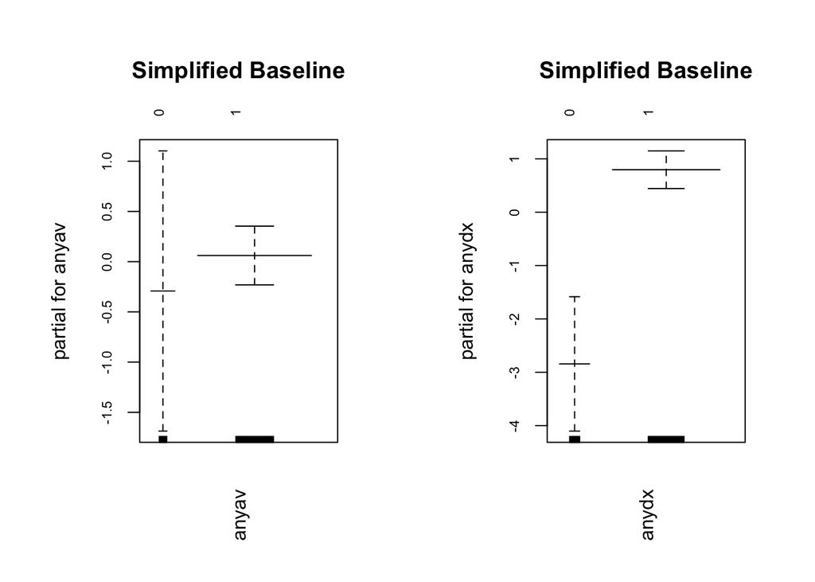

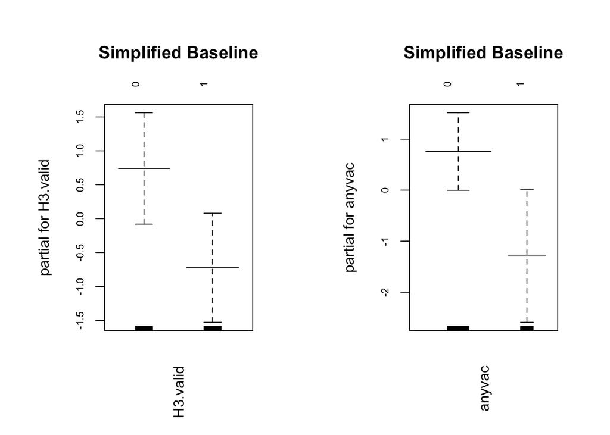

```r
## Plot the fits for each model side by side
par(mfrow = c(1, 2), las = 3, mar = c(6, 6, 6, 3), cex.axis = .7)
library(gam)
plot.gam(fit00, se = T, col = 'darkslateblue', main = 'Simplified Baseline')
```

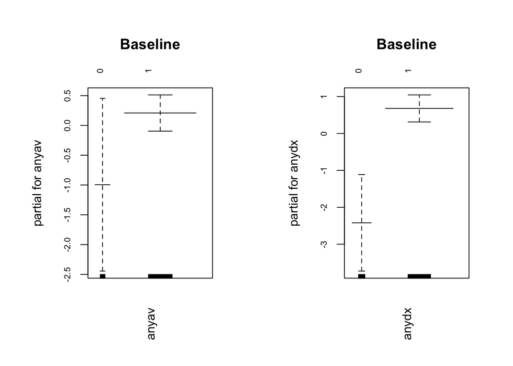

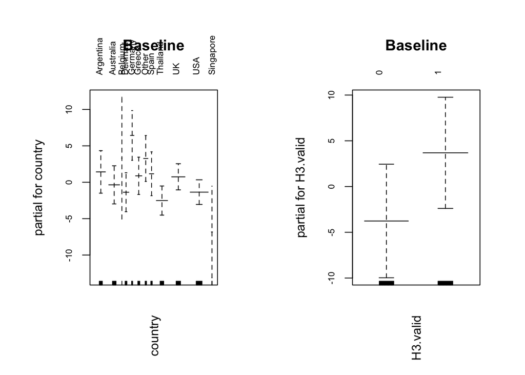

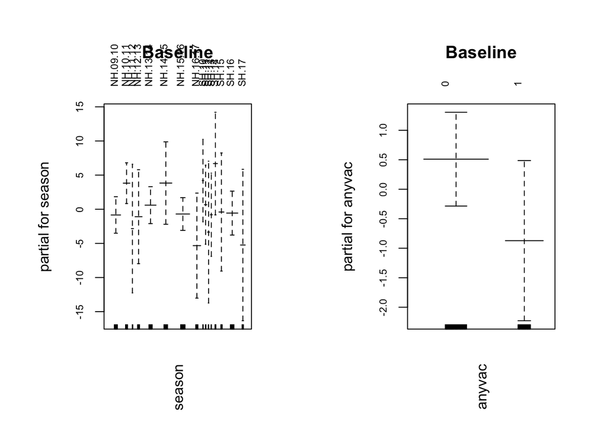

```r
plot.gam(fit0, se = T, col = 'darkslateblue', main = 'Baseline')
```

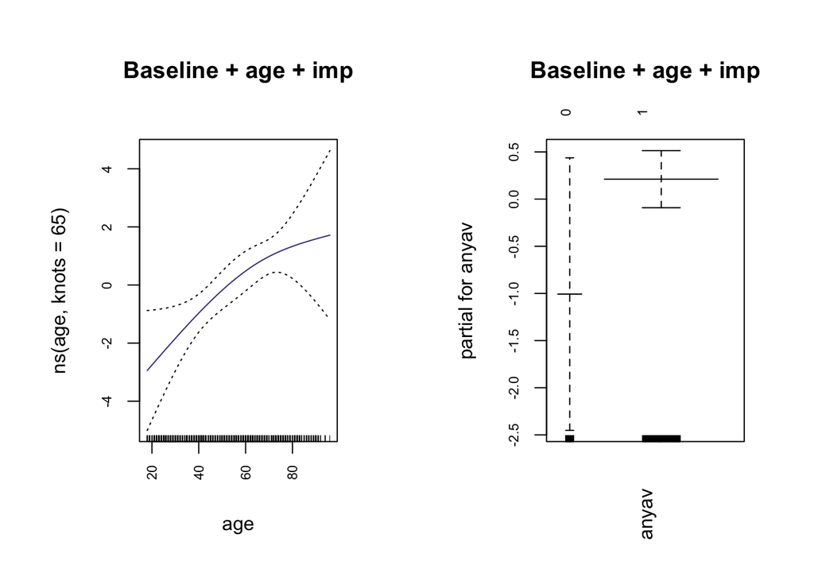

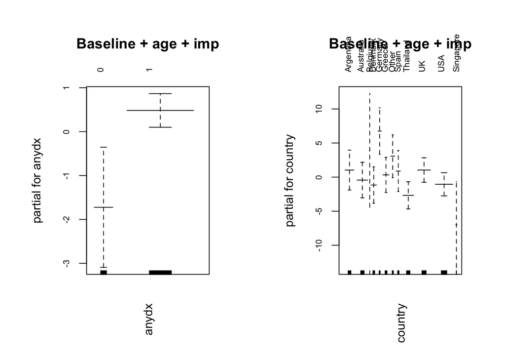

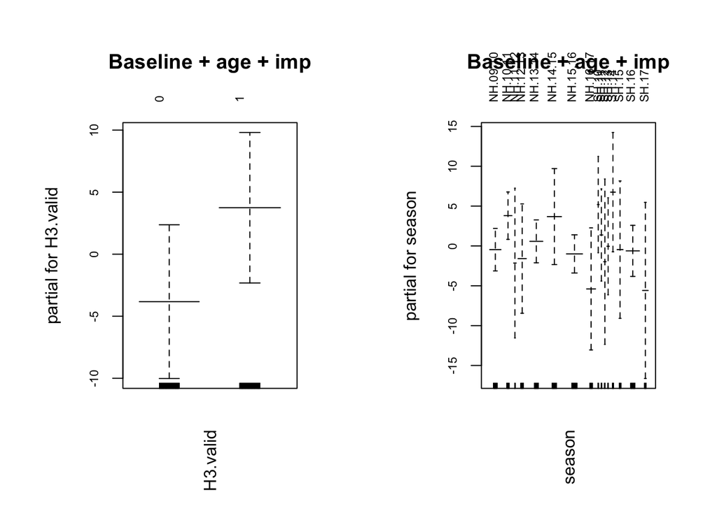

```r
plot.gam(fit1, se = T, col = 'darkslateblue', main = 'Baseline + age + imp')
```

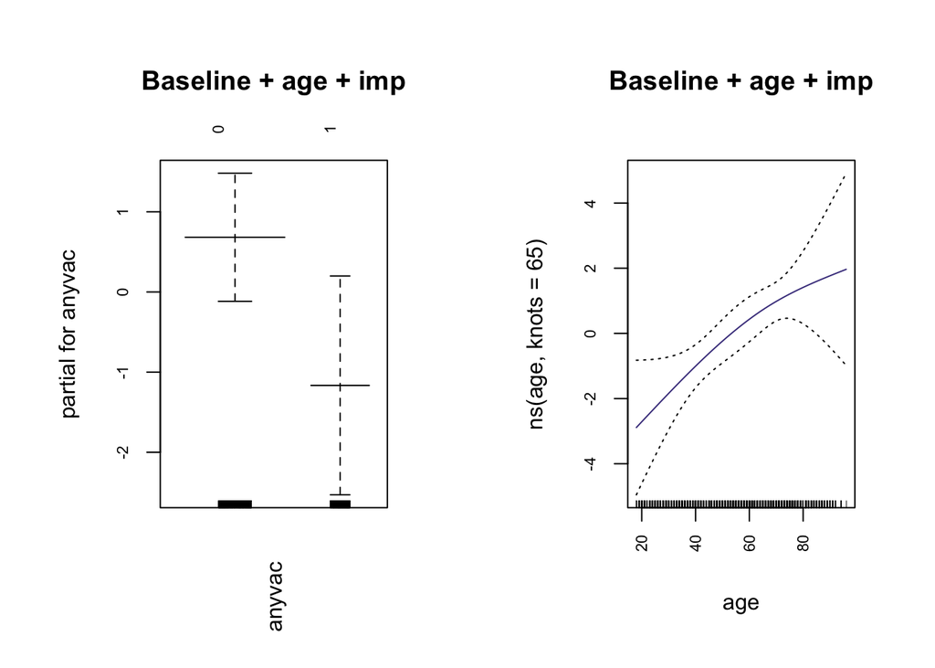

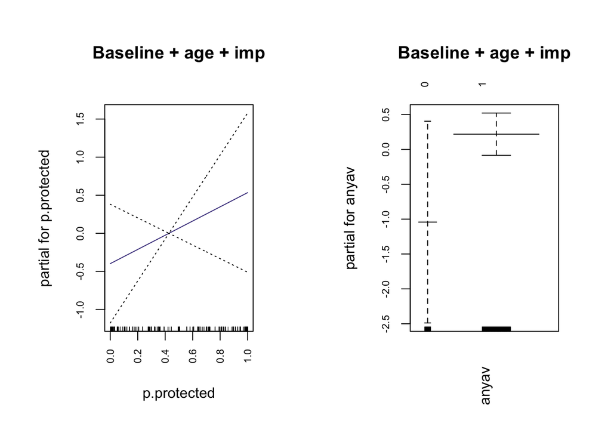

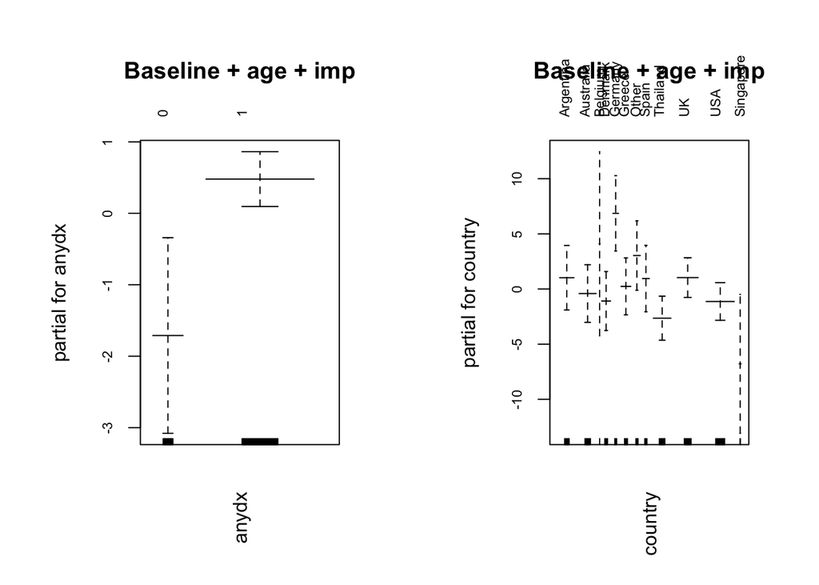

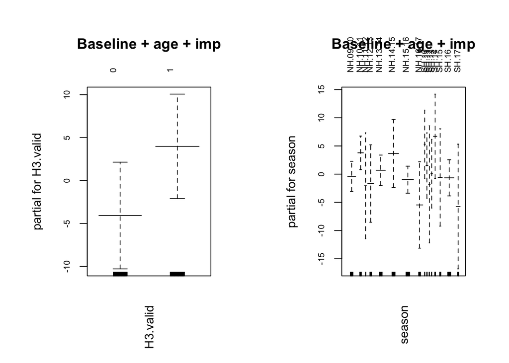

```r
plot.gam(fit2, se = T, col = 'darkslateblue', main = 'Baseline + age + imp')
```

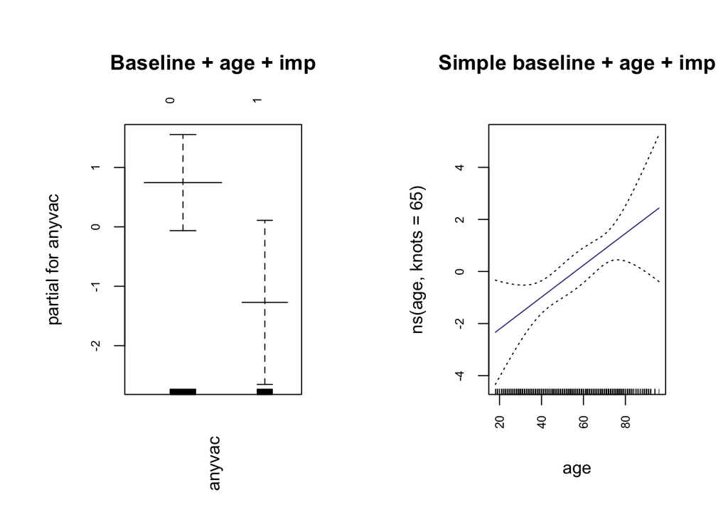

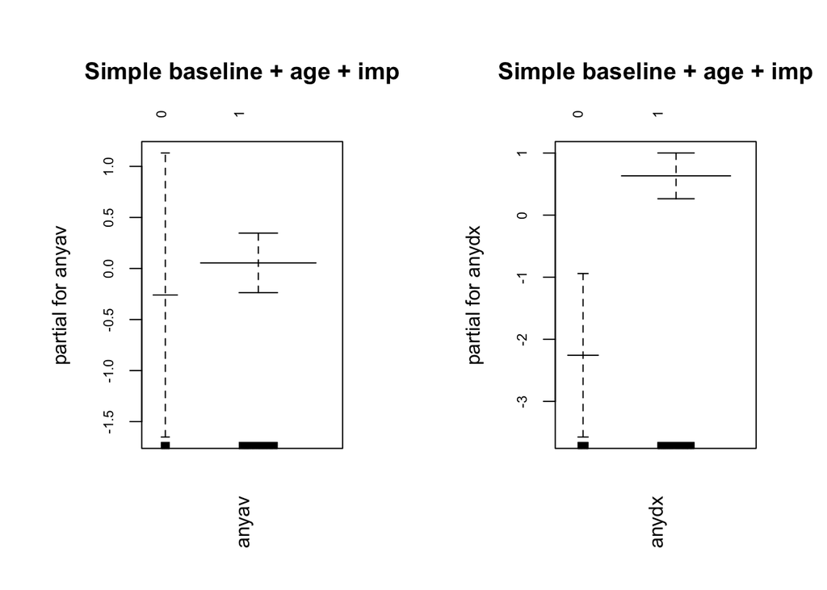

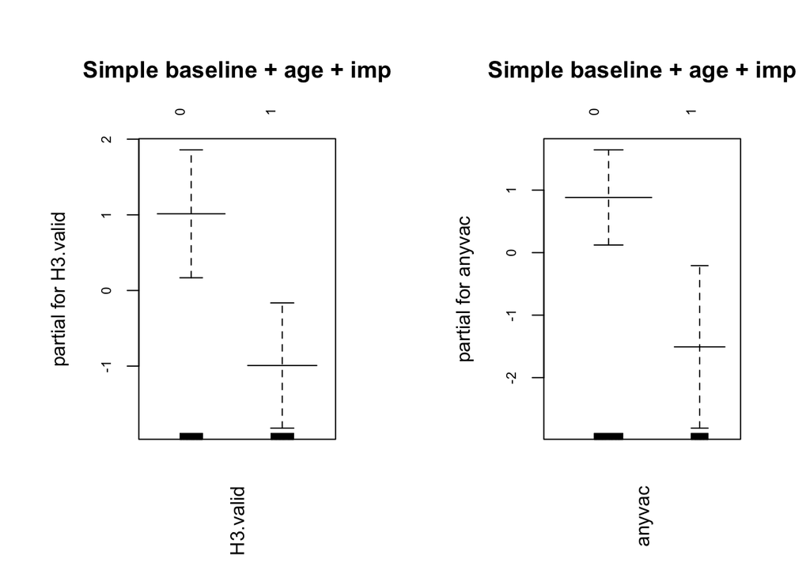

```r
plot.gam(fit3, se = T, col = 'darkslateblue', main = 'Simple baseline + age + imp')
```

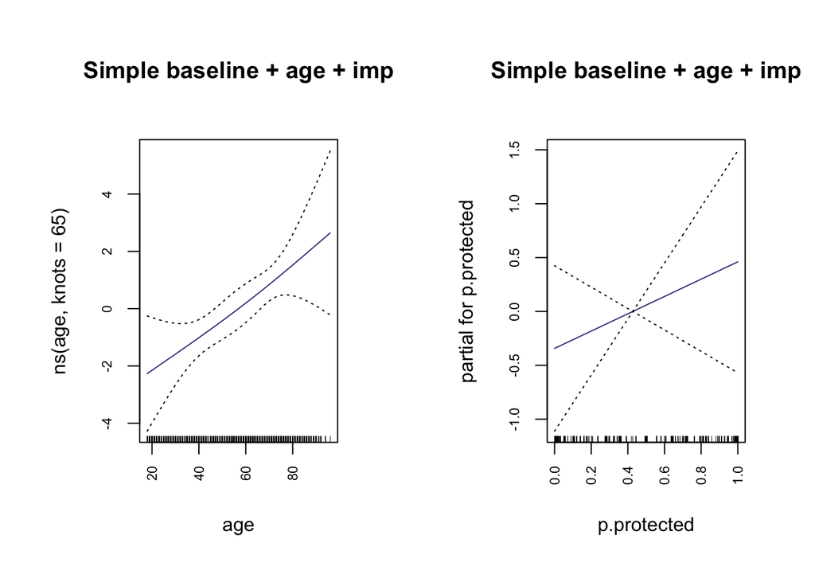

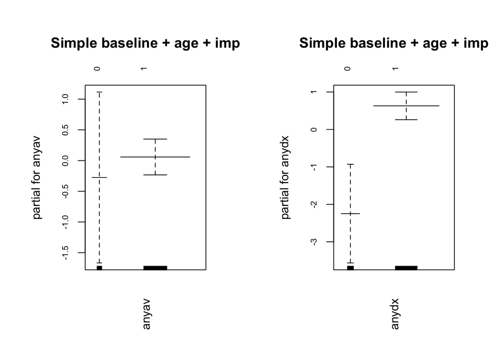

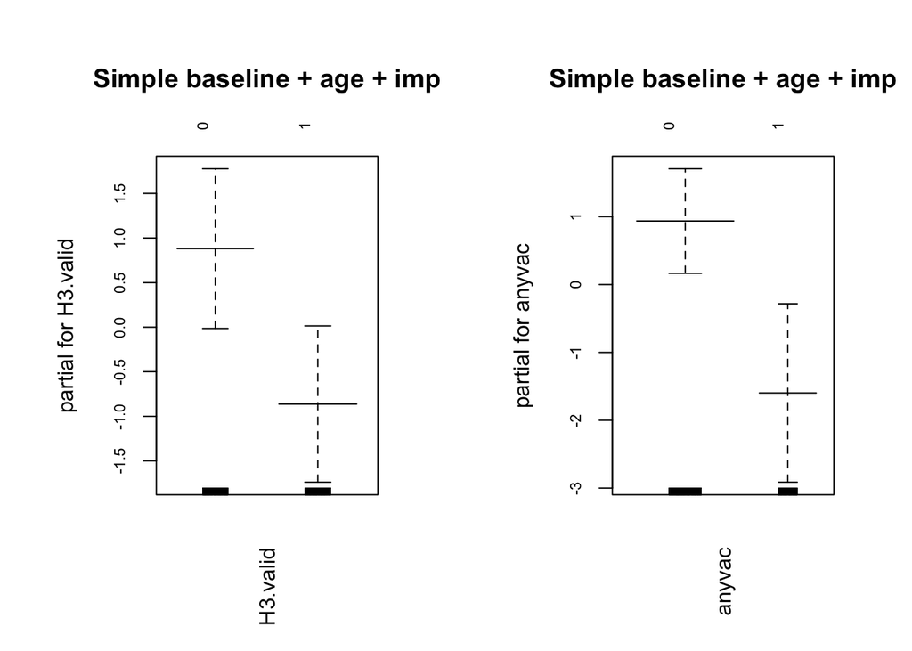

```r
plot.gam(fit4, se = T, col = 'darkslateblue', main = 'Simple baseline + age + imp')
```

```r
pdf('003hospdays_constrained.pdf')
plot.gam(fit4, se = T, col = 'darkslateblue', main = 'Simple baseline + age + imp')
dev.off()
```

```r
# Predict probs for each patient
pred00 = predict(fit00, newdata = test)
pred0 = predict(fit0, newdata = test)
pred1 = predict(fit1, newdata = test)
pred2 = predict(fit2, newdata = test)
pred3 = predict(fit3, newdata = test)
pred4 = predict(fit4, newdata = test)

# Estimate the simulated error rate
MSE = numeric(6); names(MSE) = c('simple.baseline', 'baseline', 'baeline+age', 'baseline+age+imp', 'simple.baseline+age', 'simple.baseline+age+imp')
MSE[1] = mean((pred00 - test$hospdays)^2, na.rm = TRUE)
MSE[2] = mean((pred0 - test$hospdays)^2, na.rm = TRUE)
MSE[3] = mean((pred1 - test$hospdays)^2, na.rm = TRUE)
MSE[4] = mean((pred2 - test$hospdays)^2, na.rm = TRUE)
MSE[5] = mean((pred3 - test$hospdays)^2, na.rm = TRUE)
MSE[6] = mean((pred4 - test$hospdays)^2, na.rm = TRUE)
sort(MSE)
```

```
##             baeline+age        baseline+age+imp                baseline
##                108.1658                108.8159                111.3712
##     simple.baseline+age simple.baseline+age+imp         simple.baseline
##                116.6832                117.1418                119.8634
```

```r
AIC = c(fit00$aic, fit0$aic, fit1$aic, fit2$aic, fit3$aic, fit4$aic); names(AIC) =  c('simple.baseline', 'baseline', 'baeline+age', 'baseline+age+imp', 'simple.baseline+age', 'simple.baseline+age+imp')
del.AIC = sort(AIC - min(AIC))
del.AIC
```

```
##     simple.baseline+age simple.baseline+age+imp             baeline+age
##                0.000000                1.195911                5.897956
##        baseline+age+imp         simple.baseline                baseline
##                6.813356                6.854502               13.651882
```

```r
load('master.AIC.table.H1N1.RData')
master.AIC.table['003Hospdays',  c('simple.baseline', 'baseline', 'baseline+age', 'baseline+age+imp', 'simple.baseline+age', 'simple.baseline+age+imp')] = AIC - min(AIC)
save(master.AIC.table, file = 'master.AIC.table.H1N1.RData')
rm(master.AIC.table)
```